## Particle Swarm Optimization Package

### IE 520

## Introduction

Particle Swarm Optimization (PSO) is an optimization method used to find a *global* minimum in a multimodal design space. PSO is a direct search method inspired by nature and is of interest to researchers due to their ability to handle, among other things, objective functions that lack continuity or differentiability (gradients). PSO itself works by defining a swarm (collection) of particles that are randomly assigned a position in the design space and set loose. During each iteration, each particle evaluates the objective function using its location after which the particle with the best *global* position can share its information with the other particles. Each particle then has its own (cognitive) information and has the global (social) information. Thus, unlike other optimization algorithms that take sample the design space at a single location each iteration, PSO samples n-number of spaces every iteration where $n$ corresponds to the number of particles the user defines.

This project was an attempt to create a package in R that implemented basic particle swarm optimization on a user-defined objective function. R is not considered to be an object-oriented programming language, but rather a functional programming language, with the key differentiator being *pass-by-reference* functionality. Typically an R user would model their problem in a way that takes advantage of the vectorization approach R is optimized to do, however, R does contain a pass-by-reference class R6 and this project was in large part an attempt to create a complex modeling problem, particle swarm optimization, using the R6Class.

## Methods

This project was scheduled in three segments

1. Research on the particle swarm optimization algorithm
2. Research on the R6 class
3. Implementation and testing

The basic flow of the PSO algorithm can be seen in Figure 1 below. One key note on the algorithm is the concept of convergence. A literature review showing a *specific* idea of convergence was sparce to say the least. The best advice was below,

> Check for convergence of the iterative process. If a stopping criterion is satisfied (ie, $k = k_{max}$ or **if all the particles have converged to the best swarm solution**), stop.

Ultimately, it was decided that the standard deviation of a list of each particle’s best historical function evaluation, which is updated (if necessary) each iteration, would be calculated and compared against some standard, thus if the standard deviation of all the historical best evaluations was 0.01, the algorithm was said to converge and it exited.

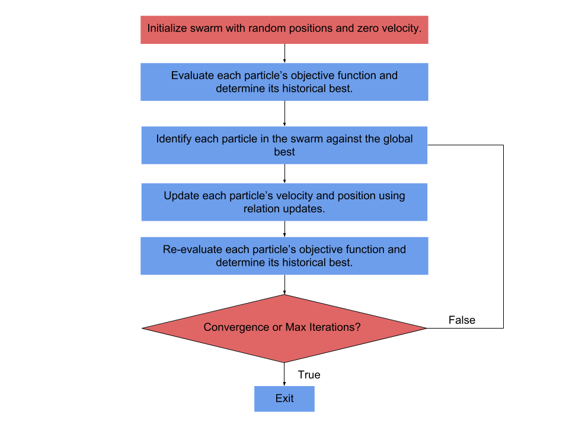

Figure 1. Flowchart of the algorithm

The first step was to create $n$ number of particles placed randomly in the design space with zero starting velocity. The objective function is evaluated for each particle and it is the first global best that dictates the directions for the next iteration (gets the particles moving).

During each iteration the velocity of a particle is updated using its local data, called *cognitive* and the global data, *social*. It is this communication across particles in the design space that makes PSO and genetic algorithms so unique. Further enhancing the unusual characteristic of PSO, random variables are used in calculating the velocity each iteration; stochastic methods like this are unusual. Finally, to prevent particles from gaining such a velocity such that they overshoot possible solutions, the limits are checked and adjusted each iteration.

Switching now to the development in R, the final PSO algorithm works by developing two R6 classes, one that describes the particle and one that holds a collection of particles, the swarm. The first few lines of the swarm class are below which show a few important features. First, it shows the basic constructor using the R6Class, which has a name and a *public* interface. Ideally, this interface is not public, however it was simply never changed.

```
# Swarm Class (Collects Particles)
Swarm = R6Class("Swarm", public = list(
    swarm = list(),

    print = function() {
        print(self$swarm)
    },
    initialize = function(obj.f, n, d) {
        # Create the list of particles
        self$swarm <- replicate(Particle$new(obj.f, d), n=n)
```

The second important point is the initialization function. This was a new feature in comparison to prior, general functions learned throughout this course. Rather than simply calling the name of the function, it was called as `Swarm$new(..args..)` which is also demonstrated here with Particle. The third point to show is the reference to an internal variable as `self$swarm`. This should be very similar and comfortable for those familiar with programming languages like Python and Java.

In addition to the Swarm and Particle classes, the main function PSO was used to tie them together.

## Discussion

It is critical to understand that algorithms like PSO **do not guarantee a solution is found**, thus analyzing solutions from multiple simulations is important. Along the same line of thought, it’s important to realize that due to the stochastic nature of the program - random starting positions and random velocity variables, the series to solution changes each simulation. Thus, to analyze the performance of the algorithms, we look at the average, variance and standard deviation of factors such as number of function evaluations and solution. Discussed further in Concluding Remarks, time was an immense factor for this project and a full analysis has not been completed.

Below is some data analysis regarding the PSO algorithm on Six-hump Camel Back Function with two design variables.

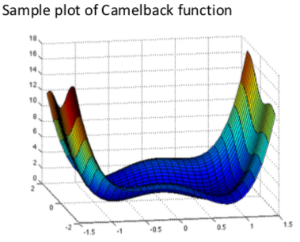

Figure 2. Six-hump Camel Back with two design variables. Credit: Vijay Kalivarapu

```
##    Simulation Objective.Function.Evaluations    Solution
##  Min.   : 1   Min.   : 480.0                 Min.   :-1.032
##  1st Qu.: 7   1st Qu.: 675.0                 1st Qu.:-1.032
##  Median :13   Median : 930.0                 Median :-1.031
##  Mean   :13   Mean   : 945.6                 Mean   :-1.031
##  3rd Qu.:19   3rd Qu.:1095.0                 3rd Qu.:-1.031
##  Max.   :25   Max.   :1515.0                 Max.   :-1.028
```

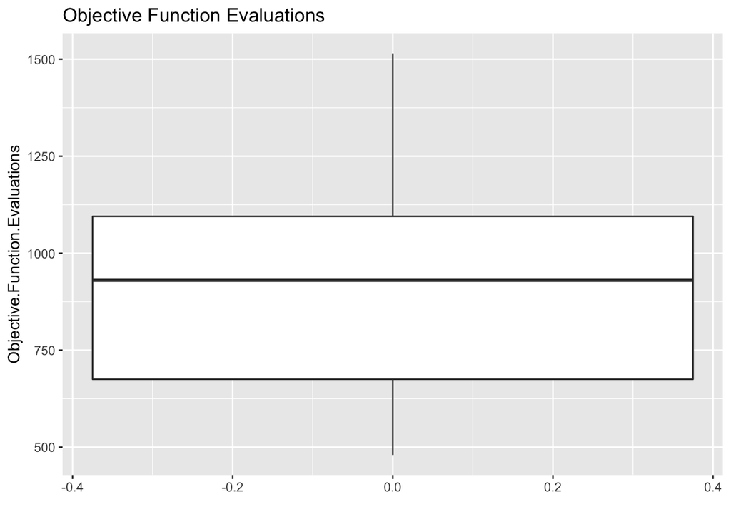

The standard deviation of the number of objective function evaluations was 310. Similarly, to analyze the solutions from the simluations,

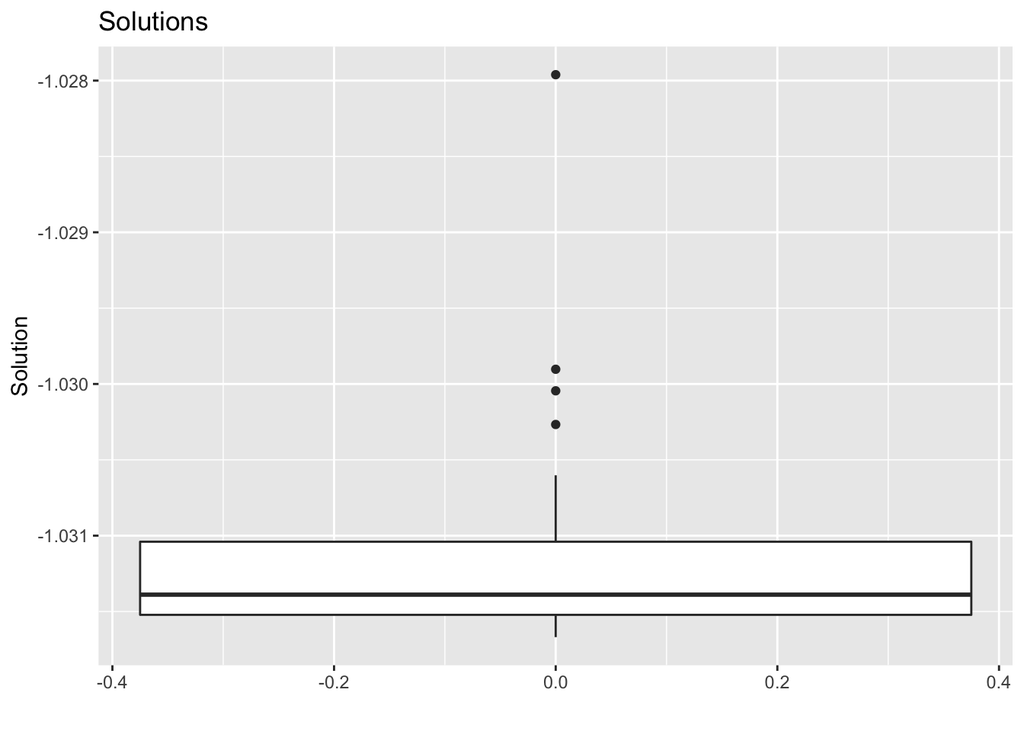

The standard deviation on the solution was 0.00081. The conclusion is that this was a successful application of PSO in R using the R6Class.

## Future Work

There are many future improvements to be made on the PSO algorithm. First, due to time constraints, the variants Inertia Weight, Cooperative Swarm and Constriction PSO were simply excluded from the package. One such reason is simplicity as time became a critical factor in completing the assignment (discussed in Concluding Remarks). The development of the variants was finished as *independent packages* and time ran out before all the variants cound be placed into a single package.

Due to the shear amount of time lost on failed attempts, secondary goals of the project were never completed. For instance, parallelization was definitely something that was to be included, however the original algorithm implementation had to be adapted to make use of the `parallel` package and time expired. After conclusion of the semester, this will be implemented out of pure curiosity and interest. Additionally, the first few attempts to get a contour plot or 2D density plot failed and that was one of the primary visuals sought for this report.

While this project made use of the R6Class it would be very interesting to see a performance comparison of PSO modeled using traditional R.

## Concluding Remarks

This project was shockingly difficult with the vast majority of the time lost on failed attempts. Ultimately, the PSO algorithm was developed in Python simply to make sure it it was correct and then translated to R (which, in and of itself was a feat) effectively doing the project twice. It was anticipated from the beginning using object oriented programming is not the convention in R and is exactly why the project was chosen - to explore this aspect of R. The primary struggle turned out to be the lack of proper or useful debugging tools in RStudio - error messages simply didn’t isolate where the program was crashing and the messages themselves lacked meaning. Stack Overflow was used extensively here.

## References

1. GitHub - https://github.com/ropensci/drake/issues/383
2. Hadley - https://adv-r.hadley.nz/r6.html
3. *Introduction to Optimum Design* - Jasbir Arora